# Challenge B

Pascale Champalaune - Lisa Forestier - Louis Sirugue

Due date: 8th of December, 2017

URL of our repository: https://github.com/LouisSirugue/CHALLENGE_B_2017

### Please note that it was not possible to upload the SIREN dataset (nor its zipped version) on GitHub (the file is larger than 25Mb). Therefore, it is needed for you to have a copy of the unzipped file (under the name of “SIREN.csv”) in the project folder that you cloned in order to be able to run the third task smoothly.

# Task 1B - Predicting house prices in Ames, Iowa (continued)

### Step 1

We are going to use the Random Forests method. The idea behind this method is that it tries a lot of different models (Decision Trees) and combines them in order to optimise the model by reducing the variance in the Trees by averaging them.

### Step 2

We train the Random Forests technique on the training data.

Type of random forest: regression  
Number of trees: 500  
No. of variables tried at each split: 24  
Mean of squared residuals: 797703297  
% Var explained: 87.18

### Step 3

We use the Random Forests model to make predictions on the test data.

Then, we estimate a simple linear regression model based on the training data, from which we deleted the missing observations and the ID feature. We use the variables that were in the best regression we made during the first challenge.

We plot the predictions given both by the Random Forests model and the simple linear regression model.

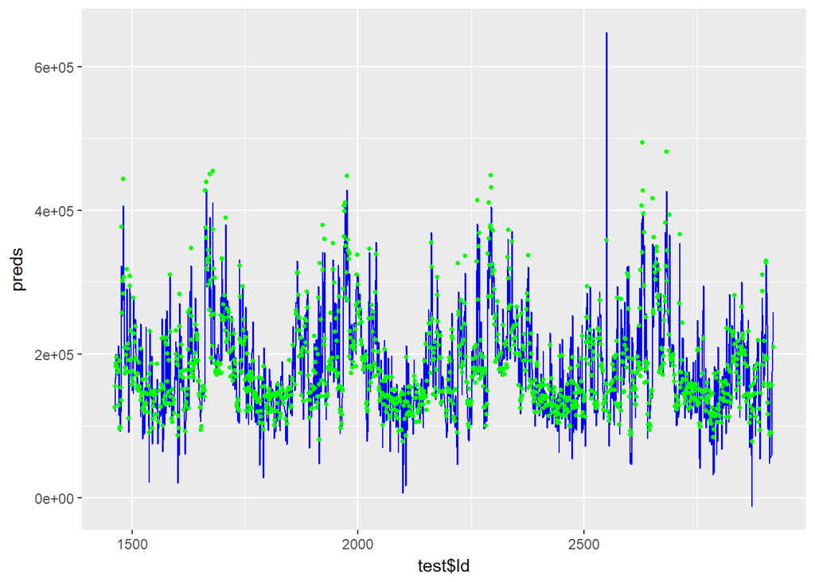

Both predictions seem to follow the same trend. However, if we do not take the extreme prediction right after 2,500 into account, the predictions given by the Random Forests model (green dots) are higher than those given by the linear model (blue line).  
The difference in their variances is difficult to identify visually.

# Task 2B - Overfitting in Machine Learning (continued)

### Step 1

Here is the summary of the low flexibility local linear model.

```
##
## Regression Data: 122 training points, in 1 variable(s)
##                 x
## Bandwidth(s): 0.5
##
## Kernel Regression Estimator: Local-Constant
## Bandwidth Type: Fixed
## Residual standard error: 1.442574
## R-squared: 0.8569977
##
## Continuous Kernel Type: Second-Order Gaussian
## No. Continuous Explanatory Vars.: 1
```

### Step 2

Here is the summary of the high flexibility local linear model.

```
##
## Regression Data: 122 training points, in 1 variable(s)
##                  x
## Bandwidth(s): 0.01
##
## Kernel Regression Estimator: Local-Constant
## Bandwidth Type: Fixed
## Residual standard error: 0.5882872
## R-squared: 0.9569811
##
## Continuous Kernel Type: Second-Order Gaussian
## No. Continuous Explanatory Vars.: 1
```

### Step 3

The following graph depicts, for the training data: + The observations from the test dataset (black dots) + The true model (black line) + The predictions given by the high flexibility local linear model (blue line) + The predictions given by the low flexibility local linear model (red line)

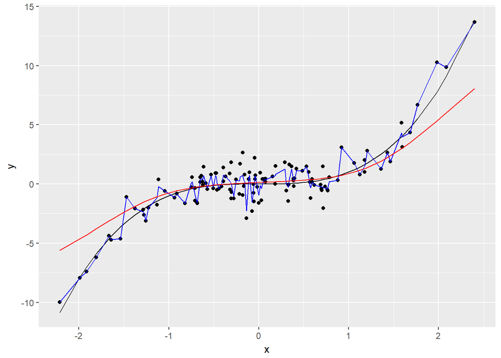

### Step 4

The predictions which are the most variable are those from the model with high flexibility (the blue line). Indeed, we can see that the line jumps from point to point almost perfectly. However, this is also the one with the most biased predictions. Indeed, the path of the predictions from the model with low flexibility is smoother, so it’s supposed to reduce the average gap between the predictions and the future values (that we would actually observe *ex post*).

### Step 5

The following graph depicts, for the test data:  
+ The observations from the test dataset (red dots)  
+ The true model (red line)  
+ The predictions given by the high flexibility local linear model (green line)  
+ The predictions given by the low flexibility local linear model (blue line)

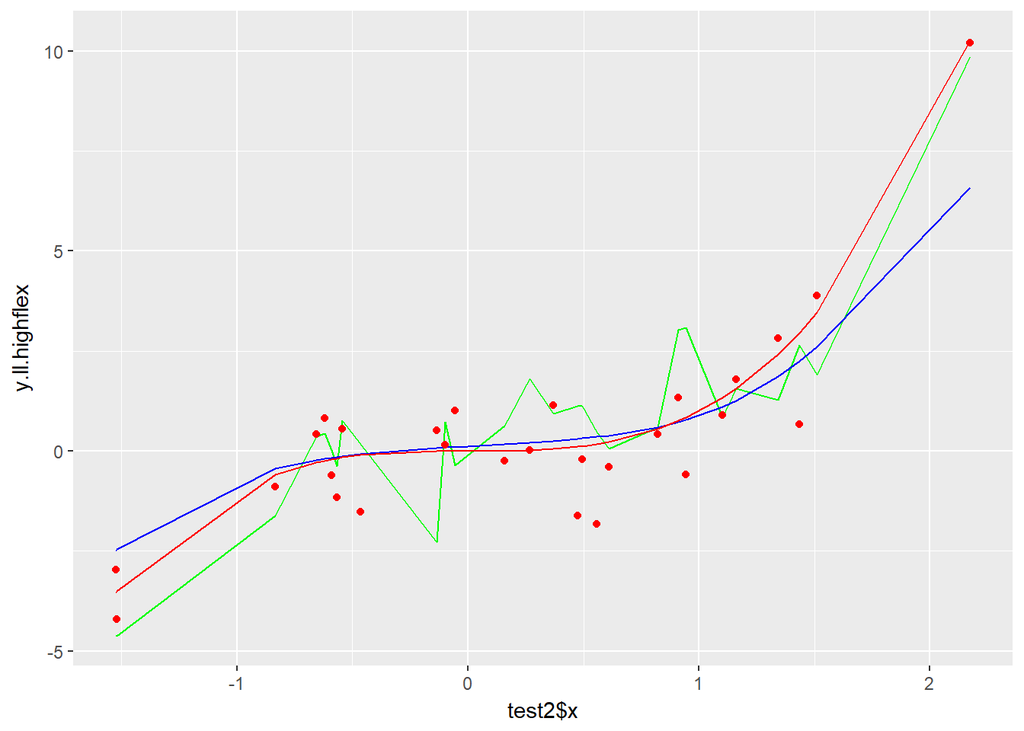

The predictions which are the most variable are those from the model with high flexibility (the green line). Indeed, we can see that the predictions are highly volatile, compared to the predictions given by the low flexibility model (blue line).  
However, the high flexibility model gives the most biased predictions. Indeed, the gaps between the red dots and the green line seem to greater on average than the gaps between the red dots and the blue line. This means that the low flexibility model may lead to less biased predictions.

### Step 6

We create a vector of bandwidth going from 0.01 to 0.5 with a step of 0.001.

It has a length equal to 491.

### Step 7

We estimate a local linear model on the training data with each bandwidth.

We obtain 491 different models: one for each bandwidth.

### Step 8

We compute the MSE on the training data, and this for each bandwidth.

We obtain a vector of 491 different MSEs, one for each model.

### Step 9

We compute the MSE on the test data, and this for each bandwidth.

Again, we obtain a vector of 491 different MSEs, one for each model.

### Step 10

We plot how the Mean Squared Errors on the training and test data change when the bandwidth increases. The blue line corresponds on the MSEs of the training data, whereas the orange line shows the change in the MSEs as the bandwidth increases.

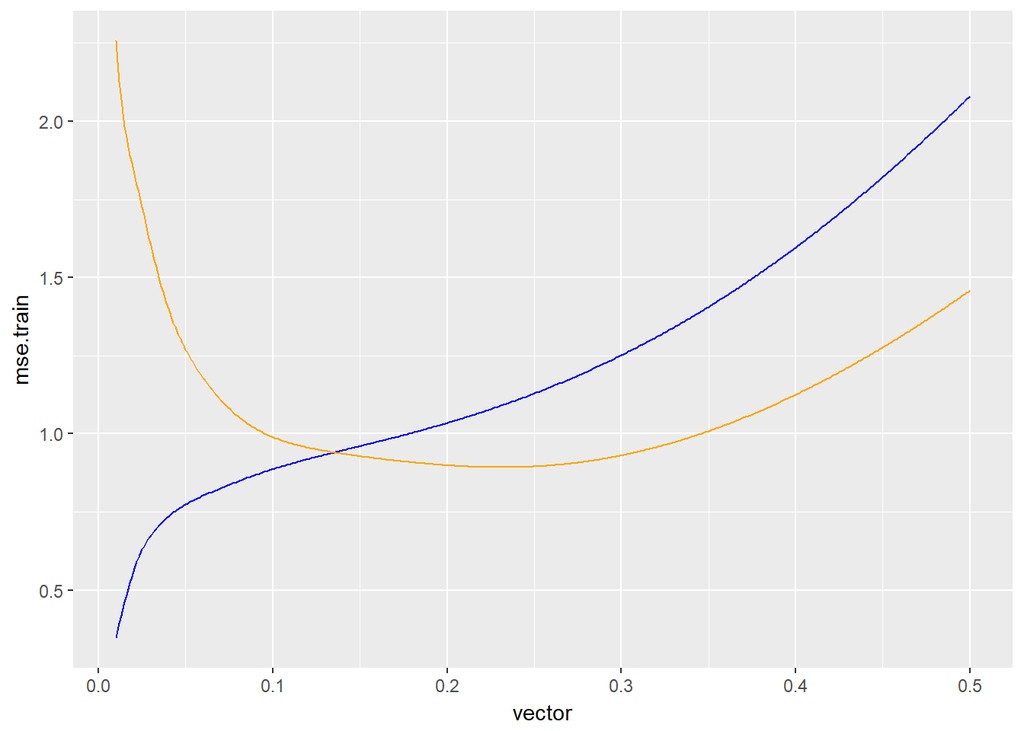

First, the lower the bandwidth, the more flexible the model. This explains why the blue line starts almost at the origin of the graph: a curve illustrating a model with full flexibility will connect all the dots, so the Mean Squared Error will be equal to zero. For the same reason, the MSE will increase as the bandwidth increases, as the curve will get smoother.  
However, as the bandwidth is low, the MSE will be very large because of the bias, as illustrated in the fifth step. The MSE will decrease as the bandwidth increases, until a certain threshold: when the bandwidth is too large, the curve is too smooth (and resembles more and more to an affine function). In our case, the optimal bandwidth would be the one at which the MSE is minimised, that is, when the slope of the orange curve is equal to zero (i.e. visually, around a 0.23 bandwidth).

# Task 3B - Privacy regulation compliance in France

### Step 1

We import the CIL dataset.

### Step 2

By viewing the data and ordering it by postcode, two problems arise:  
- Some companies who nominated a CIL gave a non-French postal code.  
- The data was not coded properly: some observations have the postal code and the city inverted, or simply the postal code was misreported.  
As only 13 observations are concerned, we proceed to a manual modification of the data on Excel, as it appears as simpler and more efficient.

| dept | Freq |
| --- | --- |
|  | 61 |
| 01 | 134 |
| 02 | 106 |
| 03 | 71 |
| 04 | 74 |
| 05 | 54 |
| 06 | 260 |
| 07 | 61 |
| 08 | 82 |
| 09 | 21 |
| 10 | 103 |
| 11 | 93 |
| 12 | 89 |
| 13 | 469 |
| 14 | 259 |
| 15 | 54 |
| 16 | 123 |
| 17 | 151 |
| 18 | 85 |
| 19 | 54 |
| 20 | 96 |
| 21 | 149 |
| 22 | 114 |
| 23 | 32 |
| 24 | 84 |
| 25 | 145 |
| 26 | 137 |
| 27 | 114 |
| 28 | 96 |
| 29 | 183 |

[output cut: 68 more lines]

Note that there are 61 missing observations.

### Step 3

After running this command, the “system.time” function allows us to say that the process took 20.84 minutes. We have a 4Gb RAM, with available 3.78Gb. On a MacBook Air with an 8Gb RAM, the command should run faster. That’s why we kept 300,000 rows in each chunk. We hope it will fit in 10 minutes on your computer.

```
## [1] 2117
```

There are only 2,117 observations in the merged dataset. We suspect that the SIREN dataset was not properly coded: indeed, if the SIRET was put in the SIREN column, the loop could not detect it.  
We run another loop in order to select the 9 first figures of each observation in the column SIREN, and run the first loop again using the new variable SIREN2 that we created.

By running the command, we get the following error message: “Error: cannot allocate vector of size 781 Kb”. The vector is too large for R to handle it. (If you wish, refer to the RMarkdown file.)

Therefore, we use the merged data set that we found in the first place, that is, *MERGEDDATA*.

### Step 4

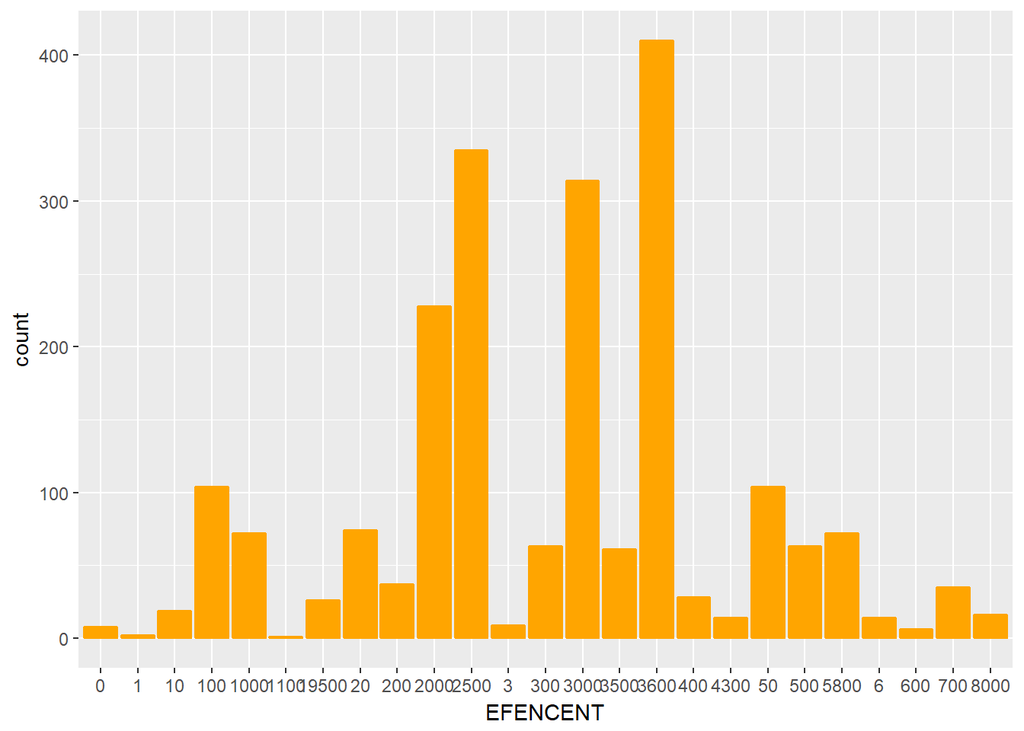

There is no clear pattern to draw from this graph. Indeed, using the SIREN number, a company that has several annexes in France (like Quick, that has a great number of restaurants) appears several times in the data set. Therefore, it may be over-represented in the histogram.

We can use the values of the number of employees in each annex, using the *EFETCENT* variable.

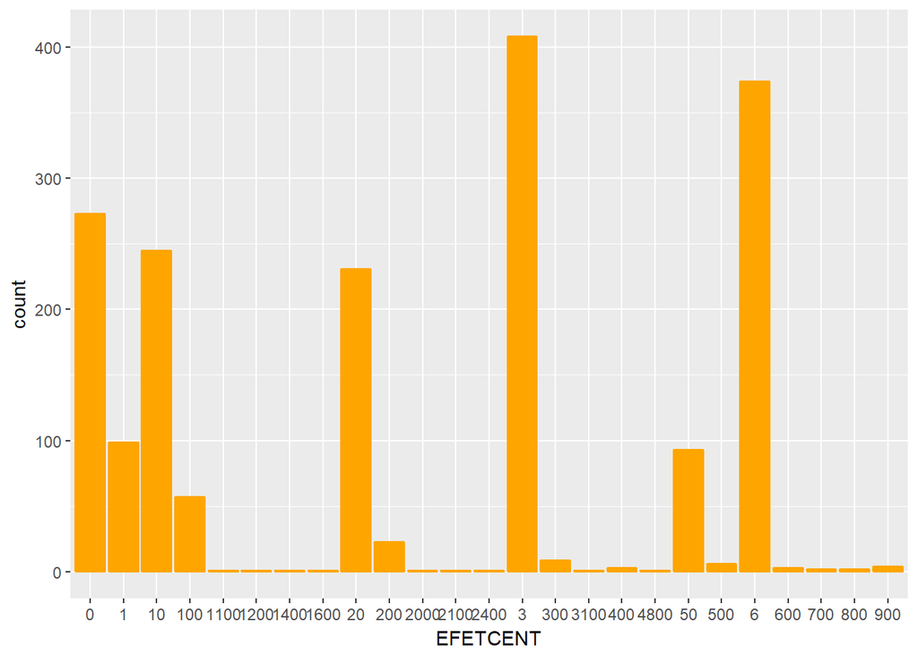

There is still no clear pattern. Indeed, we do not have precise values of the number of employees for each annex. Only an order of magnitude is given.  
Still, we expected the number of companies that nominated a CIL to be greater for larger companies than for smaller ones. We think that the histogram would have shown this if the data were more precise.